# High Dimensional Cyto Workshop

## Welcome, blast off

[figure not shown]

workshop on github

(https://github.com/tercen/highdimcyto_workshop)

## Agenda

- Intro to Tercen concepts (Module 1)
- Quality control (Module 2)
- Dimension reduction (Module 3)
- Clustering (Module 4)
- Differential testing (Module 5)
- Use your own data (Module 6)

## Module One

## Researchers’ Challenges

- Get control
- Handle large data sizes
- Integrate any database
- Visualize and interact
- Knowing what algorithm to use
- Understanding the particularities of an algorithm

[figure not shown]

## Tools evolution

- Calculators, log tables, abacus (*homo homini*)
- Excel and Graphpad (*homo australopithecus e.g. Lucy*)
- Tercen (*homo habilis*)
- Unknown (*homo sapien*)

[figure not shown]

## Thus….

[figure not shown]

## Features

- Store
- Compute
- Visualize

[figure not shown]

## Concepts and terms

- measurement (e.g. marker value)
- variable (e.g. marker/channel)
- observation (e.g. samples)
- annotation (e.g. of marker or sample)

all are factors!!!

## Wide format

| event_id | marker_1 | marker_2 |
| --- | --- | --- |
| event_1 | 10 | 12 |
| event_2 | 50 | 45 |
| event_3 | 25 | 30 |

## Long format

| event_id | marker_id | measurement |
| --- | --- | --- |
| event_1 | marker_1 | 10 |
| event_2 | marker_1 | 50 |
| event_3 | marker_1 | 25 |
| event_1 | marker_2 | 12 |
| event_2 | marker_2 | 45 |
| event_3 | marker_2 | 30 |

## Computed table

| ds0.mean | channel_id |
| --- | --- |
| 28.33 | marker_1 |
| 29 | marker_2 |

## Relational algebra

- how to define a relation between two Tables
- operators create new Tables (but also relations)
- relations between tables
- more info (https://en.wikipedia.org/wiki/Relational_algebra)
- be careful of the vocabulary
- need only understand the concepts

## Universal table

- Tercen sees all the tables as one large integrated table

## Wrangling

- visual wrangling
- data wrangling
- computational wrangling

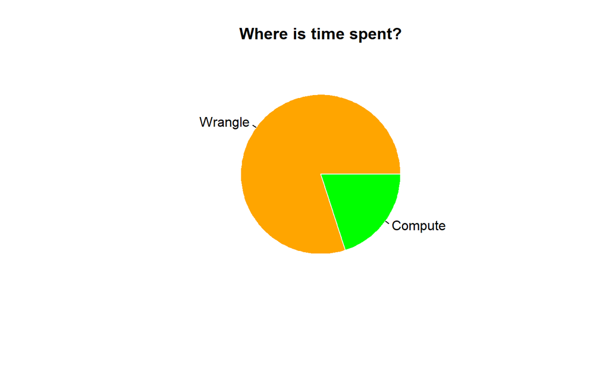

## Let’s start

- does everyone have the chrome browser installed?
- how many have a laptop with Windows?
- how many have a laptop with Linux?
- how many have a Mac?
- how many do not have a laptop?
- how many have excel, or libreoffice?

## Let’s start

Use chrome and go to:

https://test.tercen.com/

login: `lucy`

password: `habilis`

## Set up

- Create a project
  - use `module1 intro`
- Click on the newly created project
  - There is a new menu on the left
    - `Create a data set`
    - `Create a workflow`
    - `Upload a file`
    - `Import a workflow`

## Download the data for workshop

To download the data perform the following:

- click on https://raw.githubusercontent.com/tercen/highdimcyto_workshop/master/data/bodenmiller.csv
- right click and “Save As” onto desktop
- same thing for https://raw.githubusercontent.com/tercen/highdimcyto_workshop/master/data/Bcells1_01.csv

## Create the data in Tercen

- click on `Create a data set`
- browse to the data set on your desktop
- click on `OK`

## Create a workflow in Tercen

- click on `Create a workflow`
- give `module1 intro` as workflow name
  - a white canvas appears

## Add table

- right click on canvas and choose `Add`
- select `Table`
- select `bodenmiller`
  - a table step appear on the canvas
- right click on the new table step and choose `Rename`
  - rename it what you like, suggestion: `bodenmiller`

## Add data step

- right click on table step and select `Add`
- select `Data step`
  - Data step opens

## Configure data step

- drag-n-drop `measurement` to y-axis
- drag-n-drop `Time` to col
- drag-n-drop `marker_name` to row
- drag-n-drop `measurement` to color
- select `heatmap` in drop down menu
- re-size the heatmap

## Welcome to Tercen

[figure not shown]

…welcome to Tercen…

## Navigating heatmap

- scrolling rows
- scrolling columns
- squashing/expanding rows
- squashing/expanding columns
- squashing/expanding cell/datapoint

## Color palettes

- different types
- different values

## Adding more factors

- group_id, sample_id, patient_id
- marker_class, marker_channel

## Bar graphs (sample replicates)

- create a bar graph

## Line graphs (marker profiles)

- create a marker profile

## Pairwise marker plots

- create a marker vs marker

## Save workflow

- save icon on workflow tab
- icon disappears when saved

## Project Navigation

To go up: The top left icon allows you to navigate to up one level

- click on folder icon, to get up to project
- click on people icon, to get up to team

## Module Two Quality Control

## Recap

- motivation
- table concept
- teams, projects, workflows
- visual wrangling (i.e. projections) using cross-tab

## Module Two

- why QC the data?
- create a workflow “module2 QC”
- load Bcells dataset
- run flowai
- exclude the bad cells

## Module Three Dimension Reduction

## Recap

- loaded data
- created a projection
- ran flowai
- removed bad cells

## Module Three

- why reduce dimensions?
- create a workflow “module3 dimreduction”
- load Bodenmiller dataset
- run tsne, umap and pca
- tsne vs umap discussion

## TSNE vs UMAP

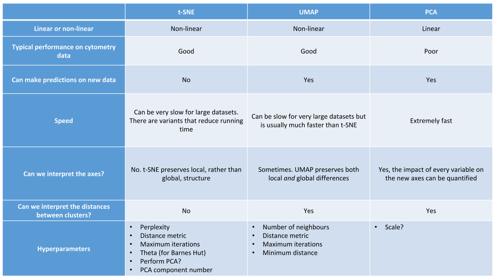

## Coffee break

[figure not shown]

## Module Four Clustering

## Recap

- selected data
- defined a projection
- ran upmap, tsne, pca
- defined a projection for the output, plot
- colored by a factor

## Module Four

- automated vs manual
- create a workflow “module4 clustering”
- load GvHD dataset
- run flowsom tuning
- cluster metric discussion

## Clustering Metrics

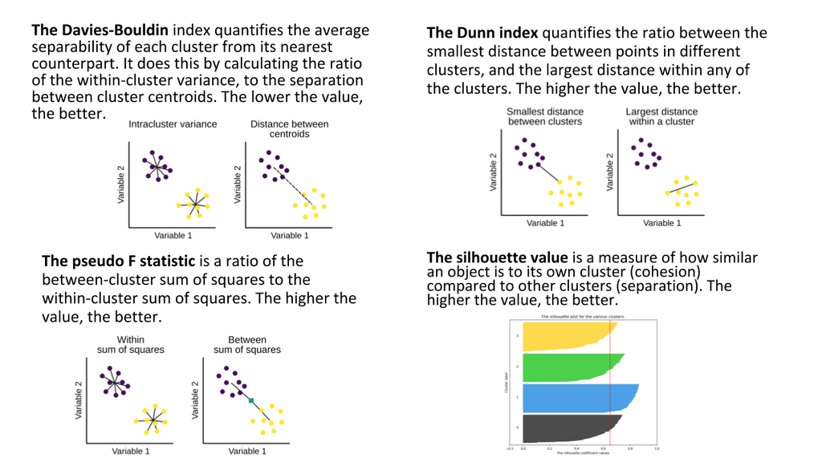

## Silhouette Metric

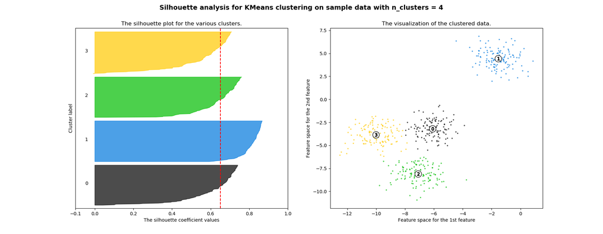

## Module Five Differential Analysis

## Recap

- seleted data
- defined a projection
- ran flowsom
- ran flowsom (with tuning)
- defined a projection for the output

## Module Five

- why use differential analysis?
- create a workflow “module5 diff analysis”
- load bodenmiller dataset
- run diffcyto
- differential cyto discussion

## Freedom

[figure not shown]

## Lunch

[figure not shown]

## Module Six

- one-2-one sessions
- practice
- use you own data

## Guides

[figure not shown]

[figure not shown]